# Beyond Turing: the wider Julia ecosystem

**Estimated time**: 1-1.5 hours | **Optional session** | **Requires**: MCMC

# Introduction

Everything so far has gone through [Turing.jl](https://turinglang.org/), and for most work that is the right choice. But when you go back to your own models you will hit cases where Turing is not what you want: a sampler it does not implement, an automatic differentiation backend that falls over on your model, or a deployment where you would rather not carry the whole stack.

Turing sits on top of a set of packages you can also use directly, and the interface between them is simpler than you might expect. It is a function that returns a log-density.

# Objectives

In this session you will:

1. See that the log-density function is the common interface across the ecosystem
2. Fit the SIR model with DynamicHMC, without Turing involved at all
3. Understand how to choose an automatic differentiation backend
4. Know which alternative samplers exist and when to reach for them
5. Know what else is available for handling and checking results

# Setup

## Source file

The source file of this session is located at `sessions/julia_ecosystem.qmd`.

## Load libraries

```julia
using DifferentialEquations ## for differential equations
using Distributions ## for probability distributions
using DataFrames ## for data frames
using CSV ## for reading data
using Random ## for random numbers
using Plots ## for plots
using StatsPlots ## for statistical plots
using DrWatson ## for datadir()
```

# The log-density is all you need

Turing’s `@model` macro and `~` syntax make Bayesian models concise and readable. Underneath, though, all Turing does is evaluate a log-density function: the same log-posterior you built by hand in the first session.

The Julia ecosystem has a standard interface for such functions, LogDensityProblems.jl. Any function conforming to it can be sampled by a range of MCMC packages. Knowing the pattern means you are not locked in to a single framework.

**NoteComing from R?**

The same layering exists in R, though it is less visible. `rstan` and `cmdstanr` are interfaces to Stan, which compiles your model down to a log-density and a gradient; [BridgeStan](https://roualdes.github.io/bridgestan/) exposes that log-density directly, which is the closest R equivalent to what this session does.

Where Julia differs is that the layers are ordinary Julia packages rather than a separate compiled language, so you can mix and match them, and read the source when something goes wrong.

**Important**

Almost everything in Bayesian computation reduces to two things: a function that returns $\log p(\theta) + \log p(y \mid \theta)$, and a way to differentiate it. Frameworks differ in how pleasantly they let you write the first and how well they do the second.

# From manual log-posterior to standard interface

In the introduction, we wrote a function that simulates the SIR model and returns the log-likelihood:

```julia
# The synthetic epidemic from the introduction session
epi1 = CSV.read(datadir("epi1_synthetic.csv"), DataFrame)

function sir_ode!(du, u, p, t)
    R_0, D_inf = p
    β = R_0 / D_inf
    ν = 1.0 / D_inf
    S, I, R = u
    N = S + I + R

    du[1] = -β * S * I / N
    du[2] = β * S * I / N - ν * I
    du[3] = ν * I
end

function simulate_and_loglik(R_0, D_inf, data; init_state = [999.0, 1.0, 0.0], tspan = (0.0, 30.0))
    prob = ODEProblem(sir_ode!, init_state, tspan, [R_0, D_inf])
    sol = solve(prob, Tsit5(), saveat = data.time)
    I = sol[2, :]
    loglik = sum(logpdf.(Poisson.(max.(I, 1e-10)), data.obs))
    return (I = I, loglik = loglik)
end
```

```
simulate_and_loglik (generic function with 1 method)
```

To use this with DynamicHMC.jl, we need a callable struct, which is an object that acts as a function. It takes a named tuple of parameters (provided by the transformation layer) and returns the log-posterior:

```julia
using LogDensityProblems, TransformVariables
using DynamicHMC, LogDensityProblemsAD, TransformedLogDensities

struct SIRPosterior{T}
    data::T
end

function (p::SIRPosterior)(θ)
    R_0, D_inf = θ.R_0, θ.D_inf
    # Priors
    lp = logpdf(Uniform(1, 20), R_0) + logpdf(Uniform(1, 14), D_inf)
    isinf(lp) && return lp  # Outside prior support
    # Likelihood
    result = simulate_and_loglik(R_0, D_inf, p.data)
    return lp + result.loglik
end
```

**TipCode explainer: callable structs**

The `(p::SIRPosterior)(θ)` syntax makes `SIRPosterior` callable. Having created `posterior = SIRPosterior(data)`, you can write `posterior(θ)` just as if it were a function. This is how you attach data to a log-density without using a global variable.

TransformedLogDensities.jl then wraps this callable with parameter transformations and automatically provides the `LogDensityProblems` interface that DynamicHMC expects.

**TipExercise: check the log-posterior by hand**

Before sampling anything, convince yourself the posterior does what you expect.

1. Create `posterior = SIRPosterior(epi1)` and evaluate it at `(R_0 = 2.5, D_inf = 2.0)`.
2. Evaluate it again at `(R_0 = 15.0, D_inf = 2.0)`. Which is larger, and does that match the data?
3. Now try `(R_0 = 0.5, D_inf = 2.0)`, which is outside the prior. What comes back, and which line of the function produced it?

**TipSolution**

At `R_0 = 0.5` you get `-Inf`, from `logpdf(Uniform(1, 20), 0.5)`. The `isinf(lp) && return lp` line then returns immediately rather than running the ODE solver. That guard matters: without it you would waste a solve on parameters the prior has already ruled out, and the solver might fail outright on nonsensical input.

# Sampling with DynamicHMC.jl

DynamicHMC.jl is a standalone NUTS implementation. It uses TransformVariables.jl to map constrained parameters to unconstrained space, which NUTS requires:

```julia
# Create the posterior
posterior = SIRPosterior(epi1)

# Define parameter transformations (constrained → unconstrained)
# R_0 ∈ (1, 20), D_inf ∈ (1, 14)
trans = as((R_0 = as(Real, 1.0, 20.0), D_inf = as(Real, 1.0, 14.0)))

# Wrap with transformations and automatic differentiation
transformed_posterior = TransformedLogDensity(trans, posterior)
∇posterior = ADgradient(:ForwardDiff, transformed_posterior)

# Sample
Random.seed!(42)
results = mcmc_with_warmup(Random.default_rng(), ∇posterior, 2000)

# Extract samples (back in constrained space)
samples = [TransformVariables.transform(trans, col) for col in eachcol(results.posterior_matrix)]
R_0_samples = [s.R_0 for s in samples]
D_inf_samples = [s.D_inf for s in samples]

println("R_0: mean = $(round(mean(R_0_samples), digits=2)), std = $(round(std(R_0_samples), digits=2))")
println("D_inf: mean = $(round(mean(D_inf_samples), digits=2)), std = $(round(std(D_inf_samples), digits=2))")
```

```
R_0: mean = 2.32, std = 0.03
D_inf: mean = 1.98, std = 0.04
```

**TipCode explainer: why the transformation is needed**

NUTS follows gradients, so it needs to move through an unconstrained space. If it proposed $R_0 = -3$, the prior would return `-Inf`, the gradient would be meaningless, and the sampler would stall at the boundary.

`as(Real, 1.0, 20.0)` supplies a map from the whole real line onto $(1, 20)$, so the sampler works in an unbounded space while your log-density only ever sees values inside the prior support. `TransformedLogDensity` also adds the log Jacobian of that map, without which you would be sampling a subtly different distribution.

Turing does exactly this for you whenever you write `R_0 ~ Uniform(1, 20)`. Here you can see it happening.

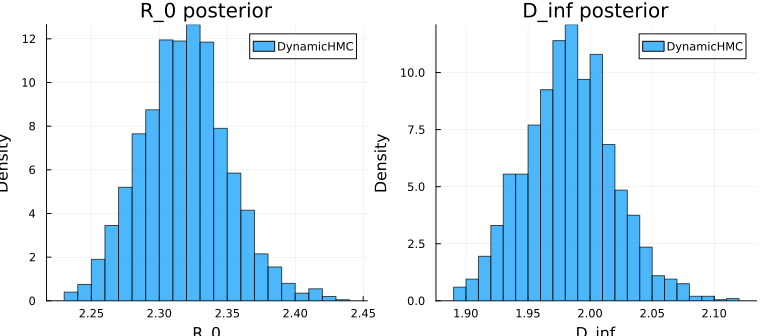

```julia
p1 = histogram(R_0_samples, normalize=:pdf, xlabel="R_0", ylabel="Density",
               title="R_0 posterior", label="DynamicHMC", alpha=0.7)
p2 = histogram(D_inf_samples, normalize=:pdf, xlabel="D_inf", ylabel="Density",
               title="D_inf posterior", label="DynamicHMC", alpha=0.7)
plot(p1, p2, layout=(1, 2), size=(800, 350))
```

Same data, same log-posterior, same NUTS algorithm, and no Turing involved.

**TipExercise: compare against Turing**

Fit the same model with Turing’s `NUTS()` as you did in the MCMC session, and compare the posterior means and standard deviations against the DynamicHMC results above.

They should agree to within Monte Carlo error. If they do not, which of the two would you suspect first, and how would you check?

**TipSolution**

They should agree: both are sampling the same posterior with the same algorithm, so any difference beyond Monte Carlo error points to a specification difference rather than a sampler difference.

The first thing to check is the priors. It is easy to write `Uniform(1, 20)` in one place and `truncated(Normal(2.5, 1.5), lower=1)` in the other and then conclude, wrongly, that the samplers disagree. Compare the log-density at a fixed $\theta$ under both implementations. If those differ, the problem is in the model.

# Choosing an automatic differentiation backend

Gradient-based samplers need $\nabla \log p(\theta \mid y)$. You almost never write that by hand: an automatic differentiation package derives it from your code. Which package you use matters more than you might expect, because they fail in different ways.

| Backend | Mode | Suits | Watch out for |
| --- | --- | --- | --- |
| **ForwardDiff** | forward | few parameters, roughly under 50 | cost scales with number of parameters |
| **Zygote** | reverse | many parameters | breaks on mutating code (`du[1] = ...`) |
| **Enzyme** | reverse | performance-critical work | fast, but error messages are hard going |
| **Mooncake** | reverse | a modern reverse-mode option | newer, still maturing |

The rule of thumb is about dimension. Forward mode costs roughly one extra evaluation per parameter, so it is excellent for a handful of parameters and hopeless for a neural network. Reverse mode costs roughly a constant multiple of one evaluation regardless of dimension, which is why machine learning uses it throughout.

You select a backend through ADTypes.jl, which every part of the ecosystem now understands:

```julia
using ADTypes

sample(model, NUTS(; adtype = AutoForwardDiff()), 1000)   # the default
sample(model, NUTS(; adtype = AutoZygote()), 1000)        # reverse mode
```

**Warning**

This is not hypothetical. The universal differential equations session trains a neural network inside an ODE with ForwardDiff, and gets away with it only because the network is deliberately tiny: 33 parameters, chosen partly so that forward mode stays affordable. Widen the network and forward mode becomes the bottleneck, because each parameter costs another pass through the model.

If a gradient-based sampler or optimiser slows to a crawl, or stops working altogether, after you change your model, the AD backend is one of the first things to suspect.

**TipExercise: which backend would you pick?**

For each of these, decide whether you would start with forward or reverse mode:

1. The SIR model from this session, with two parameters.
2. The SEIT4L model, with six parameters.
3. A model with a time-varying transmission rate given a separate value for each of 100 weeks.
4. A neural network embedded in an ODE, with a few hundred weights.

**TipSolution**

1 and 2 are firmly forward-mode territory: with two or six parameters ForwardDiff is simple and fast, and this is why it is Turing’s default.

3 is the interesting case at 100 parameters. Forward mode will work but is starting to cost; reverse mode is likely faster. This is the region where it is worth measuring rather than guessing.

4 needs reverse mode. Forward mode costs roughly one extra pass through the model per parameter, so a few hundred parameters means a few hundred passes for every gradient, where reverse mode needs a constant number. The UDE session stays on the forward side of that line by keeping its network to 33 parameters, which is the same trade-off seen from the other direction.

# Other samplers

Once your model implements the LogDensityProblems interface, a range of samplers becomes available:

| Package | What it offers |
| --- | --- |
| DynamicHMC.jl | NUTS, with a warmup that copes well with awkward posteriors |
| AdvancedHMC.jl | flexible HMC variants; the engine inside Turing |
| AdvancedMH.jl | Metropolis-Hastings and RAM, as used in the PMCMC session |
| Pathfinder.jl | fast variational approximation, useful for initialising MCMC |
| MicroCanonicalHMC.jl | microcanonical Langevin sampler |

You do not have to leave Turing to use several of these. A compatible sampler can be wrapped for use with a Turing model, which is how the PMCMC session uses robust adaptive Metropolis:

```julia
using AdvancedMH
sample(model, externalsampler(AdvancedMH.RobustAdaptiveMetropolis()), 5000;
       num_warmup = 5000, check_model = false)
```

`num_warmup` matters here: an adaptive sampler needs warmup iterations to adapt in, and `externalsampler` passes them through to the wrapped sampler.

**NotePathfinder, and why initialisation matters**

Pathfinder finds an approximate posterior quickly by following the optimisation path towards the mode. It is rarely accurate enough to report on its own, but it is very good at producing starting points for MCMC, which matters most for the slow, badly mixing chains you met in the PMCMC session, where burn-in is expensive.

**TipExercise: swap the sampler**

The point of the interface is that the sampler is now a swappable part. Keep `∇posterior` exactly as it is and sample it with AdvancedHMC instead of DynamicHMC:

```julia
using AdvancedHMC
n_samples, n_adapts = 2000, 1000
initial_θ = [0.0, 0.0]  # unconstrained space, so zeros are a fine start
samples, stats = sample(
    AdvancedHMC.NUTS(0.8), ∇posterior, initial_θ, n_samples, n_adapts
)
```

You will need to transform the samples back with `TransformVariables.transform` as above before you can compare them. Do the posterior means match?

Then think about what you had to change to swap samplers, and what you did not.

**TipSolution**

The means should match to within Monte Carlo error, because both packages implement NUTS against the same log-density and gradient.

What changed was the sampler call. What did not change: the model, the priors, the transformation, the AD backend, or the gradient. That is the whole point of the interface. It also means that if two samplers disagree by more than Monte Carlo error, the thing they share is not the suspect, so look at the one part you altered.

The exact API differs between packages (argument order, how warmup is specified, what comes back), so expect to read the documentation each time. The interface standardises the model, and it does not standardise the sampler.

# Working with the results

Whatever produced your samples, you still have to check and summarise them.

- [FlexiChains.jl](https://juliabayes.org/FlexiChains.jl/stable/) is what Turing returns by default, and what this course uses: R̂, effective sample size, MCSE and trace plots, as in the diagnostics session. It keeps a vector-valued variable whole instead of flattening it into one column per element.
- [ArviZ.jl](https://julia.arviz.org/) is a Julia interface to the ArviZ ecosystem, and is worth knowing if you also work in Python or want its diagnostic plots.
- [PosteriorDB](https://github.com/sethaxen/PosteriorDB.jl) provides reference posteriors, which are useful for checking that an implementation is correct.

# The rest of the stack

The mechanistic side of these models has its own ecosystem, most of which you have already been using without necessarily noticing:

- [DifferentialEquations.jl](https://docs.sciml.ai/DiffEqDocs/stable/) for the ODE solving throughout the course
- [SciMLSensitivity.jl](https://docs.sciml.ai/SciMLSensitivity/stable/) for differentiating through a solver, which is what makes gradient-based fitting of ODE models possible
- [JumpProcesses.jl](https://docs.sciml.ai/JumpProcesses/stable/) for stochastic simulation of the kind we hand-coded in the SEITL session

# When to reach outside Turing

Most of the time, use Turing. The `@model` syntax is clearer and quicker to write, and the diagnostics tooling comes with it.

There are three situations where it is worth dropping down a layer. If you hit a Turing problem you cannot resolve, working with the log-density directly strips away everything that might be causing it, which often tells you where the fault actually lies. If you want a sampler Turing does not implement, LogDensityProblems is the way in. And if you are deploying something, a minimal stack of your model plus an AD backend plus a sampler is less to maintain than the whole framework.

# Learning points

**TipLearning points**

- Underneath any Bayesian framework is a log-density function and a way to differentiate it
- LogDensityProblems.jl is the standard interface, and implementing it opens up the ecosystem’s samplers
- The choice of AD backend is a real modelling decision: forward mode for few parameters, reverse mode for many
- Stepping outside Turing costs you convenience and the diagnostics tooling, so do it when you have a reason rather than by default

# References

- [LogDensityProblems.jl documentation](https://www.tamaspapp.eu/LogDensityProblems.jl/stable/)
- [DynamicHMC.jl documentation](https://www.tamaspapp.eu/DynamicHMC.jl/stable/)
- [TransformVariables.jl documentation](https://www.tamaspapp.eu/TransformVariables.jl/stable/)
- ADTypes.jl, the common interface for choosing an AD backend
- [Turing.jl automatic differentiation guide](https://turinglang.org/docs/usage/automatic-differentiation/)
- [SciML documentation](https://docs.sciml.ai/), the differential equation and sensitivity stack